# 7_2_SES_Exercise_Solutions

```r
library(fpp3)
```

# SES Exercise

### 1. Select the data corresponding to Argentina from the dataset `global economy`. In particular, we are going to focus on its exports, so you may extract them as well. Produce a simple time plot of the exports

```r
arg_exports <- global_economy %>%
                  filter(Country == "Argentina") %>%
                  select(Year, Exports)

arg_exports
```

```
## # A tsibble: 58 x 2 [1Y]
##     Year Exports
##    <dbl>   <dbl>
##  1  1960    7.60
##  2  1961    5.99
##  3  1962    4.69
##  4  1963    7.89
##  5  1964    5.56
##  6  1965    6.23
##  7  1966    6.65
##  8  1967    7.50
##  9  1968    6.48
## 10  1969    6.40
## # ... with 48 more rows
```

### 2. Fit a simple exponential smoothing method `ETS(A,N,N)` to the series. Plot the forecast along with the fitted values.

```r
fit <- arg_exports %>%
  model(ETS(Exports ~ error("A") + trend("N") + season("N")))

fc <- fit %>% forecast(h=8)

fc
```

```
## # A fable: 8 x 4 [1Y]
## # Key:     .model [1]
##   .model                                                    Year   Exports .mean
##   <chr>                                                    <dbl>    <dist> <dbl>
## 1 "ETS(Exports ~ error(\"A\") + trend(\"N\") + season(\"N~  2018  N(11, 8)  11.3
## 2 "ETS(Exports ~ error(\"A\") + trend(\"N\") + season(\"N~  2019 N(11, 14)  11.3
## 3 "ETS(Exports ~ error(\"A\") + trend(\"N\") + season(\"N~  2020 N(11, 20)  11.3
## 4 "ETS(Exports ~ error(\"A\") + trend(\"N\") + season(\"N~  2021 N(11, 27)  11.3
## 5 "ETS(Exports ~ error(\"A\") + trend(\"N\") + season(\"N~  2022 N(11, 33)  11.3
## 6 "ETS(Exports ~ error(\"A\") + trend(\"N\") + season(\"N~  2023 N(11, 39)  11.3
## 7 "ETS(Exports ~ error(\"A\") + trend(\"N\") + season(\"N~  2024 N(11, 46)  11.3
## 8 "ETS(Exports ~ error(\"A\") + trend(\"N\") + season(\"N~  2025 N(11, 52)  11.3
```

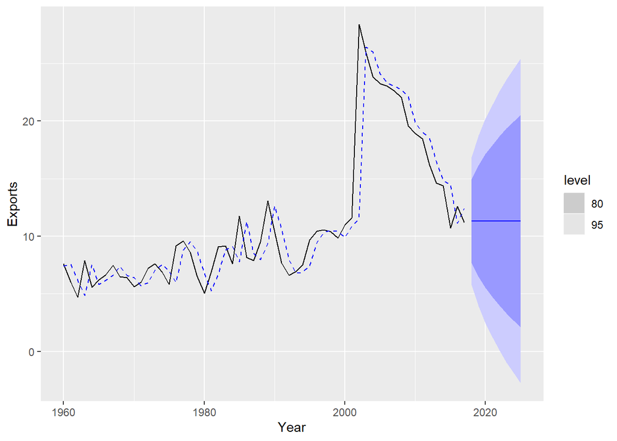

```r
fitted_vals <- fit %>% augment()

fc %>%
  autoplot(arg_exports) +
  autolayer(fitted_vals, .fitted, colour = "blue", linetype = "dashed")
```

#### * **Do you think the ETS forecast method is appropriate for this data? Why? Why not?**

As explained in session 7_1, Simple Exponential Smoothing is appropriate for data that does not have clear trend or seasonality.

The time plot reveals that this is the case, so the model seems appropriate.

### 3. How many parameters does the model have? Extract their values.

There are two parameters to every Simple Exponential Smoothing model: $\alpha$ and the initial level $l_0$.

We can inspect the values resulting from the minimisation of the SSE when the model was fitted by using the function `tidy()`

```r
tidy(fit)
```

```
## # A tibble: 2 x 3
##   .model                                                       term  estimate
##   <chr>                                                        <chr>    <dbl>
## 1 "ETS(Exports ~ error(\"A\") + trend(\"N\") + season(\"N\"))" alpha    0.886
## 2 "ETS(Exports ~ error(\"A\") + trend(\"N\") + season(\"N\"))" l[0]     7.41
```

Remember **these values have been chosen by the library `fable` as part of the model fitting process**. They are the values of the parameters that minimize the SSE.

The fact that alpha is roughly 0.89 means that the most recent observation gets assigned a weight of 0.89. The remaining 0.11 percent is split in an exponentially decreasing manner across all other observations. We can see this on equation:

$$\hat{y}_{T+1|T} = \alpha y_T + \alpha(1-\alpha) y_{T-1} + \alpha(1-\alpha)^2 y_{T-2}+ \cdots$$

### 4. Compute the standard deviation of the residuals as (see equation in html format of the notebook). See session 6_2 for more details.

$$\begin{equation}
\hat{\sigma} = \sqrt{\frac{1}{T-K}\sum_{t=1}^T e_t^2}
\end{equation}$$

- $K$ is the number of parameters estimated in the forecasting method

```r
# Compute the residuals
resid <- fit %>% augment() %>% pull(.innov)

# Remove missing values before computing the length
resid <- resid[!is.na(resid)]

sigma <- sqrt(sum(resid^2)/(length(resid)-nrow(tidy(fit))))

# Comparison with the forect distribution provided by the fable library.
# See lesson 6_2 to learn how to extract this values.
sigma == distributional::parameters(fc$Exports[1])$sigma
```

```
## [1] TRUE
```

### 5. Compute a 95% prediction interval for the first forecast using $\hat{y} \pm 1.96s$, where s is the standard deviation of the residuals computed in the previous point. See lesson 6_2 for further guidance.

Under the assumption that the forecast distribution is normal, we can compute the 95% confidence intervals using the 97.5% quantile of the standard normal distribution together with the standard deviation of the residuals.

- We use a distribution of mean 0 because our point forecast is the mean of the forecast distribution.
- We will scale the amplitude of the interval with the sd of our particular normal distribution of residuals.

The 97.5% quantile of the standard normal distribution is 1.96 (let is check it).

```r
# Check the 97.5% quantile of the normal distribution
alpha = 0.05

q_alpha_2 <- round(qnorm(1-alpha*0.5, mean = 0), 4)

q_alpha_2
```

```
## [1] 1.96
```

We now take this quantile to produce a 95% confidence interval centered around the mean of the distribution (our point forecast). For this we need to scale the quantile by the value of the standard deviation of the residuals we computed before:

```r
# Extract point forecast for h = 1
h1_fc <- fc$.mean[1]

# Compute the confidence interval centered on the point forecast
conf_int_man = c(h1_fc - q_alpha_2*sigma, h1_fc + q_alpha_2*sigma)

# Print the confidence interval
conf_int_man
```

```
## [1]  5.785663 16.860547
```

### 6. Extract the prediction interval produced by R for the first forecast (see session 6_2). How does your prediction interval compare to that?

```r
# See lesson 6_2 to learn how to extract this
fc_int <- fc %>%
  hilo() %>%
  unpack_hilo(`95%`) %>%
  select(Year, .mean, `95%_lower`, `95%_upper`)

# Inspect the output
fc_int
```

```
## # A tsibble: 8 x 4 [1Y]
##    Year .mean `95%_lower` `95%_upper`
##   <dbl> <dbl>       <dbl>       <dbl>
## 1  2018  11.3      5.79          16.9
## 2  2019  11.3      3.93          18.7
## 3  2020  11.3      2.45          20.2
## 4  2021  11.3      1.18          21.5
## 5  2022  11.3      0.0609        22.6
## 6  2023  11.3     -0.960         23.6
## 7  2024  11.3     -1.90          24.5
## 8  2025  11.3     -2.78          25.4
```

```r
# Extract bounds of confidence interval for 2018
conf_int_fable <- c(fc_int$`95%_lower`[1], fc_int$`95%_upper`[1])
conf_int_fable
```

```
## [1]  5.785765 16.860445
```

We would now like to compare both confidence intervals. Since we rounded the values of the quantiles of the normal function to 4, let us round the result of the multiplication to 2 decimals for comparison:

```r
# If all the components of both verctors are equal, the sum should be equal
# to 0 (vector of only FALSE booleans)
# Remember that the ! operator is equivalent to boolean negation

sum(!(round(conf_int_fable, 2) == round(conf_int_man, 2)))
```

```
## [1] 0
```

We can see that the confidence interval computed manually matches the one computed by `fable`.

### 7. Write your own function to implement simple exponential smoothing. The function should take arguments:

- `y` (the time series)
- `alpha` (the smoothing parameter $\alpha$)
- `level` (the initial lvel $l_0$)

The function should return the value of the constant flat forecasts of SES beyond the training data:

```r
my_ses <- function(y, alpha, level) {

  # Returns the forecast (final level) of simple exponential smoothing

  # ARGUMENTS:
  # @y: a vector containing the y values of our time series
  # @alpha: parameter alpha of simple exponential smoothing
  # @level: initial level of simple exponential smoothing.

  # RETURN:
  # returns the final level (i.e. the flat forecast) of simple exponential smoothing

  yhat <- numeric(length(y) + 1) # Prepares the output of the for loop

  yhat[1] <- level

  for (i in 2:(length(yhat))) {
    yhat[i] <- alpha*y[i-1] + (1-alpha)*yhat[i-1]
  }

  return(last(yhat))
}
```

It might be confusing that the code above uses yhat to hold both the values of the level and of the actual fitted values, because in simple exponential smoothing the fitted values are simply the levels shifted one step in time (see the table example table in lesson 7_1 or the forecast equation of simple exponential smoothing).

Also note that the index used for `y` within the for loop is `i-1` because we are looping over `2:length(yhat)`. Since `length(yhat) == length(y) + 1` (we defined yhat in this manner) in this manner we are sweeping over all values of `y`.

¿Does it give the same forecast as ETS()?

```r
y <- arg_exports$Exports
alpha <- tidy(fit)$estimate[1]
level <- tidy(fit)$estimate[2]

# Manually computed forecast
yhat_man <- my_ses(y, alpha, level)

# Forecast computed with fable
yhat_fable <- fc$.mean[1]

# Check whether they are equal or not
round(yhat_man, 4) == round(yhat_fable, 4)
```

```
## [1] TRUE
```

We see that it does indeed lead to the same estimate

## Additional: use `optim()` to find optimal values for the parameters of simple exponential smoothing

**8. Create a function that takes as input an estimate of $\alpha$, an estimate of $l_0$ and returns the Sum of Squared Errors (SSE):**

Pass the estimates of the paramenters $\alpha$ and $l_0$ as a vector `par` of two components. This will make the function compatible with `optim` in the next step.

```r
my_ses_sse <- function(par, y) {

  # Computes the Sum of Squared Errors of simple exponential smoothing

  # ARGUMENTS:
  # @y: a vector containing the y values of our time series
  # @par: a vector containing the parameters of the model (alpha and l_0)
  #   - par[1] is alpha
  #   - par[2] is l_0

  # RETURN:
  # @SSE: Sum of squre residuals

  alpha <- par[1]
  level <- par[2]

  n <- length(y)

  # Initialize vector to fitted values
  yhat <- numeric(n)

  yhat[1] <- level

  for(i in 2:n) {
    yhat[i] <- alpha * y[i-1] + (1-alpha) * yhat[i-1]
  }

  SSE <- sum((y - yhat)^2)

  return(SSE)
}
```

**9. Use the function `optim()` to find the optimal values of $\alpha$ and $l_0$, that is, the values that minimize the sum of square residuals:**

The function `optim()` is a general-purpose optimization function within the library `stats`. The details of its implementation are way beyond the scope of this course, but we may use it to minimize the SSE in simple exponential smoothing.

`optim()` is able to minimize a target function, but this function must have the following structure in its arguments:

`target_function(par, ...)` where:

- `par` are the parameters that `optim()` will optimize over to minimize `target_function`
- `...` are futher arguments of the `target_function`

In our case the `target_function` is `my_ses_sse` and remember we defined the signature of my_ses_sse as follows:

- `my_ses_sse(par, y)`
  - `par` is the vector of parameters ($\alpha$ and $l_0$). We will provide initial values for these parameters and `optim()` will start from this initial values trying out different values until it fulfils some minimality criteria for `my_ses_sse`.
  - `y` is the time series data (the vector of observations of the time series). This is not something that we want `optim()` to change, and therefore we pass it as a separate value.

For our purposes (minimizing SSE) we may therefore use the function as follows (see clarifications after code execution).

```r
opt <- optim(par = c(0.1, arg_exports$Exports[1]), fn = my_ses_sse, y = arg_exports$Exports)
opt
```

```
## $par
## [1] 0.8858742 7.4073016
##
## $value
## [1] 446.9863
##
## $counts
## function gradient
##       43       NA
##
## $convergence
## [1] 0
##
## $message
## NULL
```

Let us examine the output:

- `par`: is a vector providing initial values of the parameters for which we would like to find optimal values
  - We specify `0.1` as an initial value for $\alpha$ because it corresponds to an exponential smoothing method that takes sufficient past information into account (for small alpha more weight is assigned to observations in the past). This is sensible as a starting point for the search for $\alpha$.
  - We specify the first value of the series as the initial level because it is a good estimation of the level of a series. Another option would be to start with the mean value of the series.
- `value`: is the value of the function to be minimized that corresponds to the optimal parameters. In our case it is therefore the SSE for the final values of $\alpha$ and $l_0$ returned by the function.
- `counts`: indicates the amount of calls to `fn` during the iterative process followed for optimization. The bigger this number, the longer the optimization process took.
- `convergence` = 0 indicates that the optimization algorithm successfully converged.

```r
tibble(
  param = c("alpha", "l[0]"),
  optim_vals = opt$par,
  fable_vals = tidy(fit) %>% pull(estimate)
)
```

```
## # A tibble: 2 x 3
##   param optim_vals fable_vals
##   <chr>      <dbl>      <dbl>
## 1 alpha      0.886      0.886
## 2 l[0]       7.41       7.41
```

It is also not fully clear that `optim()` and `fable` are using the same optimization algorithm, but for the problem at hand they lead to very similar values.

## Wrap-up: write a function that, given only the vector of observations of the time series, fits the parameters of SES and returns the flat forecast of SES.

Having already explored how `optim()` works, we can now combine the functions `my_ses`, `optim()` and `my_ses_sse` to create a single function that both finds the optimal values of $\alpha$ and $l_0$ and produces a forecast for the next observation in the series:

```r
my_ses_full <- function(y) {

  # Fits a Simple Exponential Smoothing, returning the forecast and the optimal
  # values of the parameters alpha and l_0

  # ARGUMENTS:
  # @y: a vector containing the y values of our time series

  # RETURNS:
  # @result: a tibble dtailing the optimal values of the parameters and the forecast

  # Find optimal values for the parameters that minimize SSE
  par <- optim(c(0.1, y[1]), my_ses_sse, y = y)$par

  # Unpack optimal values of parameters
  alpha <- par[1]
  level <- par[2]

  # Return forecast and optimal value of parameters
  result <- tibble(
                ` ` = c("alpha", "level", "forecast"),
                values = c(alpha, level, my_ses(y, alpha, level))
            )

  return(result)
}
```

Let us now try the function:

```r
my_ses_full(arg_exports$Exports)
```

```
## # A tibble: 3 x 2
##   ` `      values
##   <chr>     <dbl>
## 1 alpha     0.886
## 2 level     7.41
## 3 forecast 11.3
```